# Arbeiten mit DataFrames: local global warming...

[figure not shown]

## Die Säkularstation in Potsdam

Wir arbeiten in dieser Lektion mit einer legendären Zeitreihe, die direkt vor unserer Haustür liegt: Den Aufzeichnungen der sog. [Säkularstation](https://www.pik-potsdam.de/de/produkte/infothek/telegraphenberg-d/suering-haus/sakularstation) auf dem Telegraphenberg in Potsdam. Hier werden seit über 100 Jahren Klimabeobachtungen aufgezeichnet. Wir wollen uns auf die Beobachtungen der bodennahen Temperatur und der relativen Luftfeuchte beschränken.

Bei so einer langen Zeitreihe stellt sich gleich die Frage, ob wir den Effekt der lokalen Erwärmung sehen können...aber eins nach dem anderen.

Die Daten werden über das [opendata-Portal](https://opendata.dwd.de/climate_environment/CDC/observations_germany/climate/hourly/air_temperature/historical/) des DWD bereitgestellt. Die Säkularstation hat die ID `03987`. Die Zeitreihe findet Ihr unter `../data/saekularstation/produkt_tu_stunde_18930101_20201231_03987.txt` als `csv`-Datei.

### Aufgabe: Daten einlesen

Zum Einlesen dieser Daten nutzen wir das Paket `pandas`, das Ihr bereits kurz in Lektion 1 kennengelernt habt.

```python
import pandas as pd
```

Genauer gesagt nutzen wir die Funktion `pd.read_csv`. Ruft doch einmal die Hilfe zu dieser Funktion auf.

- Über welchen Parameter teilt Ihr der Funktion mit, welches Zeichen in der Datei als Spaltentrenner verwendet wird?
- Und welches Zeichen *wird* nun in der Datei als Spaltentrenner verwendet?
- Lest auf Grundlage dieser Erkenntnis die Datei als DataFrame mit Namen `df` ein.

### Lösung

```python
df = pd.read_csv("../data/saekularstation/produkt_tu_stunde_18930101_20201231_03987.txt", sep=";")
```

### Aufgabe: Erkunden des Dataframes

Nutze die Funktionen, die du im ersten Teil kennengelernt hast, zum Erkunden des Dataframes.

- Wieviele Zeilen und Spalten hat der Dataframe?
- Welche Struktur hat der Dataframe? Was gibt es für Spalten, was bedeuten sie?
- Lass Dir die ersten und letzten Zeilen des Dataframes sowie eine Zusammenfassung der Spalten anzeigen.

### Lösung

```python
# Zeilen, Spalten
df.shape
```

```
(1122010, 6)
```

```python
df.info()
```

```
<class 'pandas.core.frame.DataFrame'>
RangeIndex: 1122010 entries, 0 to 1122009
Data columns (total 6 columns):
 #   Column       Non-Null Count    Dtype
---  ------       --------------    -----
 0   STATIONS_ID  1122010 non-null  int64
 1   MESS_DATUM   1122010 non-null  int64
 2   QN_9         1122010 non-null  int64
 3   TT_TU        1122010 non-null  float64
 4   RF_TU        1122010 non-null  float64
 5   eor          1122010 non-null  object
dtypes: float64(2), int64(3), object(1)
memory usage: 51.4+ MB
```

```python
df.head()
```

|  | STATIONS_ID | MESS_DATUM | QN_9 | TT_TU | RF_TU | eor |
| --- | --- | --- | --- | --- | --- | --- |
| 0 | 3987 | 1893010101 | 5 | -12.3 | 84.0 | eor |
| 1 | 3987 | 1893010102 | 5 | -10.9 | 84.0 | eor |
| 2 | 3987 | 1893010103 | 5 | -9.9 | 84.0 | eor |
| 3 | 3987 | 1893010104 | 5 | -9.4 | 84.0 | eor |
| 4 | 3987 | 1893010105 | 5 | -8.9 | 84.0 | eor |

```python
df.tail()
```

|  | STATIONS_ID | MESS_DATUM | QN_9 | TT_TU | RF_TU | eor |
| --- | --- | --- | --- | --- | --- | --- |
| 1122005 | 3987 | 2020123119 | 3 | 1.3 | 82.0 | eor |
| 1122006 | 3987 | 2020123120 | 3 | 1.9 | 80.0 | eor |
| 1122007 | 3987 | 2020123121 | 3 | 1.4 | 84.0 | eor |
| 1122008 | 3987 | 2020123122 | 3 | 1.2 | 88.0 | eor |
| 1122009 | 3987 | 2020123123 | 3 | 1.4 | 90.0 | eor |

```python
df.describe()
```

|  | STATIONS_ID | MESS_DATUM | QN_9 | TT_TU | RF_TU |
| --- | --- | --- | --- | --- | --- |
| count | 1122010.0 | 1.122010e+06 | 1.122010e+06 | 1.122010e+06 | 1.122010e+06 |
| mean | 3987.0 | 1.956569e+09 | 5.014505e+00 | 8.873072e+00 | 7.868548e+01 |
| std | 0.0 | 3.694889e+07 | 1.783774e+00 | 8.368938e+00 | 1.817310e+01 |
| min | 3987.0 | 1.893010e+09 | 1.000000e+00 | -2.680000e+01 | 7.000000e+00 |
| 25% | 3987.0 | 1.925010e+09 | 5.000000e+00 | 2.600000e+00 | 6.700000e+01 |
| 50% | 3987.0 | 1.957010e+09 | 5.000000e+00 | 8.800000e+00 | 8.400000e+01 |
| 75% | 3987.0 | 1.989010e+09 | 5.000000e+00 | 1.490000e+01 | 9.400000e+01 |
| max | 3987.0 | 2.020123e+09 | 1.000000e+01 | 3.860000e+01 | 1.000000e+02 |

### Datum und Zeit im DateFrame

Wir wollen unseren DataFrame zunächst ein wenig aufräumen: weniger sperrige Spaltennamen verwenden und Spalten rausschmeißen, die in unserem Kontext nicht brauchen.

```python
# Etwas weniger sperrige Spaltennamen verwenden
df.columns = ['id', 'datetime', 'qn9', 'temp', 'rh', 'eor']
# Nur die Spalten mit Datum, Temperatur und relativer Luftfeuchte behalten
df = df[["datetime", "temp", "rh"]]
```

Ein schneller Plot...

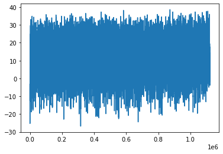

```python
df.temp.plot()
```

Ein ganz schönes Gezappel, aber gut: Es sind ja auch über 100 Jahre stündlicher Daten! Was wir aber vermissen: die Zeitinformation auf der x-Achse. Dazu fehlen zwei Schritte:

```python
# datetime-Spalte auch als datetime interpretieren
df.datetime = pd.to_datetime(df.datetime, format="%Y%m%d%H")
# datetime als index verwenden
df = df.set_index("datetime")
```

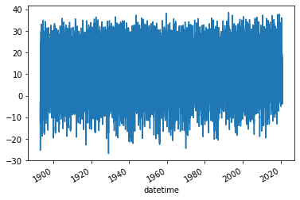

```python
df.temp.plot()
```

Ja, so ist's besser. Wir schauen uns nochmal den "Kopf" des DataFrames an und sehen, dass die Spalte `datetime` jetzt als Index fungiert.

```python
df.head()
```

| datetime | temp | rh |
| --- | --- | --- |
| 1893-01-01 01:00:00 | -12.3 | 84.0 |
| 1893-01-01 02:00:00 | -10.9 | 84.0 |
| 1893-01-01 03:00:00 | -9.9 | 84.0 |
| 1893-01-01 04:00:00 | -9.4 | 84.0 |
| 1893-01-01 05:00:00 | -8.9 | 84.0 |

Die Spalte `datetime` lässt sich nun auch nicht mehr über den Spaltennamen aufrufen...Ihr erhaltet einen `AttributeError` - aua.

```python
df.datetime
```

```
---------------------------------------------------------------------------
AttributeError                            Traceback (most recent call last)
/tmp/ipykernel_13456/2199413736.py in <module>
----> 1 df.datetime

~/miniconda3/envs/umweltdv/lib/python3.7/site-packages/pandas/core/generic.py in __getattr__(self, name)
   5476         ):
   5477             return self[name]
-> 5478         return object.__getattribute__(self, name)
   5479
   5480     def __setattr__(self, name: str, value) -> None:

AttributeError: 'DataFrame' object has no attribute 'datetime'
```

...sondern über das `index`-Attribut:

```python
df.index
```

[output not shown]

### Aufgabe

Nur zur Erinnerung an frühere Zeiten: versucht doch mal, den Datensatz in Excel oder OpenOffice Calc einzulesen und die obige Abbildung zu reproduzieren.

### Lösung

Ich hab es mal in OpenOffice Calc probiert...mit folgendem Ergebnis:

[figure not shown]

## Jahresmittelwerte darstellen

Wie oben schon angesprochen, sieht man bei über 100 Jahren stündlicher Daten erstmal nicht so viel. Schauen wir uns doch mal die Zeitreihe der Jahresmittelwerte an. Die geht in `pandas` sehr komfortabel mit Hilfe der `resample`-Funktion.

### `resample`

Kern der `resample`-Funktion ist das Zeitinterval, auf welchem die Mittelung stattfinden soll. Anschließend teilt man `pandas` mit, welche Funktion denn auf diesem Zeitintervall angewendet werden soll. Hier wäre das die Funktion `mean`. Das Ergebnis ist ein neuer DataFrame, den wir hier dfa nennen.

```python
# Jahresmittelwerte ("1a")
dfa = df.resample("1a").mean()
```

```python
dfa.info()
```

```
<class 'pandas.core.frame.DataFrame'>
DatetimeIndex: 128 entries, 1893-12-31 to 2020-12-31
Freq: A-DEC
Data columns (total 2 columns):
 #   Column  Non-Null Count  Dtype
---  ------  --------------  -----
 0   temp    128 non-null    float64
 1   rh      128 non-null    float64
dtypes: float64(2)
memory usage: 3.0 KB
```

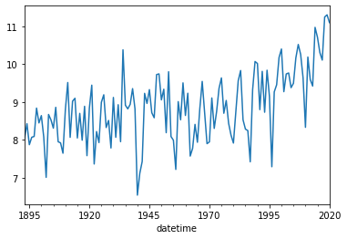

```python
dfa.temp.plot()
```